# 1. CRISP-DM의 데이터마이닝 방법론

[출처] https://en.wikipedia.org/wiki/Cross-industry_standard_process_for_data_mining

```
1) CRIP-DM(CRoss-Industry Standard Processing for Data Mining)
   데이터마이닝을 위한 업계 표준 프로세스
```

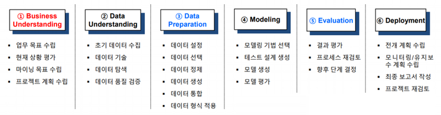

2) AI/데이터 마이닝 다양한 기법들

분류 모형(Classification Models)

어떤 기준(정답)에 의해 분석 대상을 2개 또는 3개 이상의 집단으로 분류하는 예측 모형이다. 예)- 고객이 연체를 할 것인지 안할 것 인지

- 부도예측, 기상예측, 채권등급예측 등
- 영상에서 찍힌 사진의 결과물이 사람인지 아닌지 등 분석방법에는 여러 가지 분석 방법들이 있다.

분석방법)

● 로지스틱 회귀분석(LOGIT, Logistic Regression) ● 인공신경망(ANN,) ● 사례기반추론(CBR) ● 의사결정나무(DT,Decision Trees) ● SVM(Support Vector Machines)

```python
3) 데이터 전처리
결측치(Missing Value)의 처리
너무 많은 항목이 비어 있는 변수나 너무 많은 항목이 비어 있는 레코드는 그 자체를 삭제
기타 나머지 항목에 대해서는 일반적으로 다음과 같은 값으로 대체
평균값(Mean) / 중앙값(Midian) / 최빈값(Mode)
평균값 : ( 1 + 2 + 3+ 4 + 4+ 5 + 6 + 6 + 6 + 7 +8) /11 = 4.727
중앙값 : 5
최빈값(빈도수 높은 것) : 6

정성적 변수의 정량화
각 속성은 단일변수 값(atomic value)을 갖도록 수정
정성적 변수의 경우, 0/1의 binary code로 변환해야 추후 해석이 가능
예) 주소의 변환, 성
별의 변환 등

정량적인 변수
정상적인변수
신장 , 체중, 나이
성별, 직업



정량적인 변수: 양을 측정할 수 있는 값, 숫자로 측정하고 표현하는 분석
정성적인 변수: 숫자가 아니라 말로 설명하는 분석, 물질의 성분이나 성질을 밝히기 위한 분석
```

예) 성별을 구분하기 위해서 주민번호의 데이터의 예(정성적 변수)

1,3 => 남자 , 2,4 => 여자

남 => 1, 남 => 0, 여 => 0, 여 => 1 라고 만들고

```python
4) 이상치(Outlier)의 제거
상식적으로 말이 안되거나 잘못 입력된 것으로 추정이 되는 변수 값을 조정
일괄적으로 상위10%와 하위10%에 해당하는 값들을 단일 값으로 부여하는 경우도 있음
예) 체중 80kg이상은 무조건 80Kg로, 체중 45Kg 이하는
무조건 45Kg으로
```

5) 새로운 파생변수 개발 기존의 변수를 조합하여 새로운 변수를 개발 본래는 비율변수인 변수를 의미있는 정보로 구간화하여, 새로운 명목변수로 만드는 방법

6)정규화(Normalization) 모든 입력변수의 값이 최소 0에서 최대 1사이의 값을 갖도록 조정하거나,평균을 갖는 표준균보를 갖도록 값을 조정하는 것 정규화 공식(Min-Max Normaliztion) (x-최소값) / (최대값 - 최소값)

7) 자료의 구분 과적합화(Overfitting)의 발생 가능성 학습이 너무 잘 되어서 학습 데이터에 대해서는 높은 정확도를 나타내지만 테스트 데이터나 실제 적용 시에는 성능이 떨어지는 현상

8) 과적합화의 예방방법 Hold-out data(검증) : 모형이 일반성을 갖는지 확인하기 위해 남겨두는 unknown data 통계 모형을 구축할 때, 전체 데이터가 100이라면 학습:검증=8:2 혹은 7:3 비중으로 자료를 미리 나누어 둠

9) 모형에 들어갈 후보 입력변수 선정

카이제곱 검정(Chi-square Test) 독립표본 T검정(t-Test) - 이분류 모형의 경우에 사용 분산분석(ANOVA) - 다분류 모형의 경우에 사용

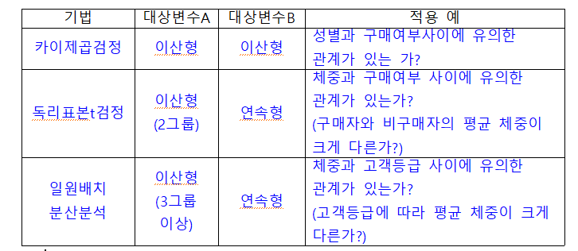

10)모집단과 표본

1.1.1.1. 모집단 (population) : 전체집합 , 관심의 대상이 되는 집단 전체

예) 우리나라 국회의원들이 소유하고 있는 모든 주택의 평균 가격은 얼마인가?

모수(parameter)

- 모집단이 가지고 있는 특징을 나타내는 수치

예) 평균 가격

전수조사(census) : 우리나라 국민을 대상으로 전부 조사하는 방법

- 모집단의 모든 개체를 전부 조사하는 방법
- 모수의 값을 가장 정확하게 알아내는 방법 : 시간과 비용 문제

1.1.1.1. 표본(Sample) : 전체 집합(모집단)에서 일부만(표본) 조사하는 방식

- 모수의 값을 알아내기 위해 추출된 모집단의 일부분
- 일반적인 통계분석에서는 모집단의 일부만 조사하여 모집단의 모수를 추측
- 100% 정확하지는 않지만, 거의 근접한 값을 제공해 줄 수 있음
- 대신 시간과 비용을 크게 절약할 수 있는 방법

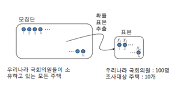

  11) 1.1. 카이제곱 검정의 해석
  - 점근 유의확률(P-value 라고 함)을 토대로 평가한다.
  - 95% 신뢰수준 하에서로 해석하고 싶으면, 유의확률 < 0.05 인지 확인
  - 90% 신뢰수준 하에서로 해석하고 싶으면, 유의확률 < 0.1 인지 확인
  - (즉 유의확률은 작으면 작을 수록 좋다)

  12) 1.1. 가설 검정기초

  1.1.1. 과학 분야에서의 증명 : 반증법에 의거해서 증명

  1.1.1. 귀무가설(H0)과 대립가설(Ha)

우리가 알고 싶은 명제(주로 A와 B는 다르다. A와 B는 차이가 있다는 등)는 대립가설로 두고,

그 반대인 귀무가설(주로 A와 B는 같다, A와 B는 차이가 없다등)이

기각됨을 보임으로서 내가 입증해 보이고 싶은 명제를 증명하는 것

예) 수도권에 거주하면 대체로 소득 수준이 높다.라는 명제가 있다면

내가 주장하고 싶은 것 - 수도권에 거주한다고 소득이 꼭 높지 않다

# 실습)

## 1.카이제곱 검정의 해석